# RNASeq_Analysis

Maximilian Greil

2 1 2022

## 0) Load and prepare data

### 0.1) Data overview

The data used in this RNA-Seq analysis was originally generated in [this study](https://www.ncbi.nlm.nih.gov/bioproject/PRJNA275655) ([SRA](https://www.ncbi.nlm.nih.gov/sra/?term=SRP055103)) and the results discussed in [this paper](https://doi.org/10.1016/j.stemcr.2015.04.012). The six generated runs can be found [here](https://www.ncbi.nlm.nih.gov/Traces/study/?acc=PRJNA275655&o=acc_s%3Aa).

The biological question was to clarify the lineage relationship between IL3Rαhigh- and IL3Rαlow precursor cells and to find potential molecules involved in their differentiation.

The utilized count matrix data was generated using [this](https://github.com/MaxGreil/rnaseq) nextflow RNA-Seq pipeline. The resulting output file `featureCounts_output.txt.gz` contains the input data for this RNA-Seq analysis.

### 0.1) First look at data

First, the input data was cleaned.

After this, the rownames contain the Ensembl version gene names. The six columns correspond to the gene counts for the six runs SRR1806626, SRR1806627, SRR1806628, SRR1806629, SRR1806630 and SRR1806631.

The first three runs SRR1806626, SRR1806627 and SRR1806628 are generated from IL3Rαhigh precursor cells, runs SRR1806629, SRR1806630 and SRR1806631 are generated from IL3Rαlow precursor cells.

|  | SRR1806626 | SRR1806627 | SRR1806628 | SRR1806629 | SRR1806630 | SRR1806631 |
| --- | --- | --- | --- | --- | --- | --- |
| ENSG00000223972.5 | 0 | 0 | 0 | 0 | 0 | 0 |
| ENSG00000227232.5 | 15 | 2 | 4 | 5 | 6 | 6 |
| ENSG00000278267.1 | 0 | 0 | 0 | 0 | 0 | 0 |
| ENSG00000243485.5 | 0 | 0 | 0 | 0 | 0 | 0 |
| ENSG00000284332.1 | 0 | 0 | 0 | 0 | 0 | 0 |
| ENSG00000237613.2 | 0 | 0 | 0 | 0 | 0 | 0 |

## 1) Exploratory analyis and visualization

### 1.1) Create a PCA plot colored by the condition of interest

A variance-stabilizing transform was applied to the counts and a principal component analysis (PCA) was implemented to visualize sample-level differences.

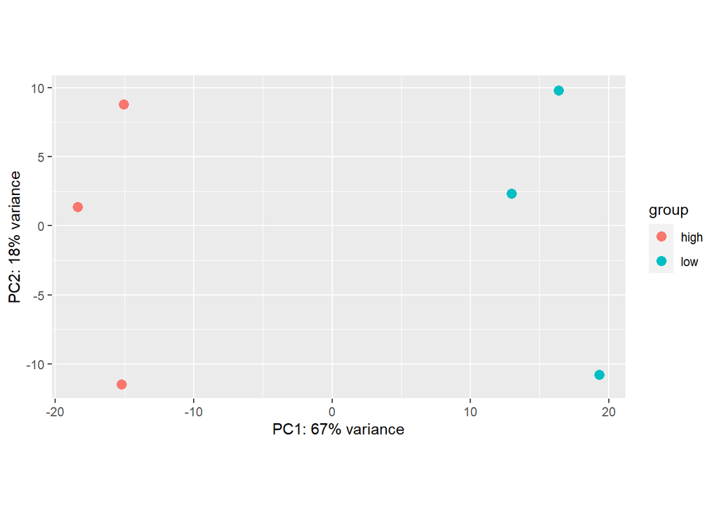

### 1.2) Heatmap of Poisson distances between samples

To confirm the results of the PCA analysis, the sample-level distance was calculated via hierarchical clustering.

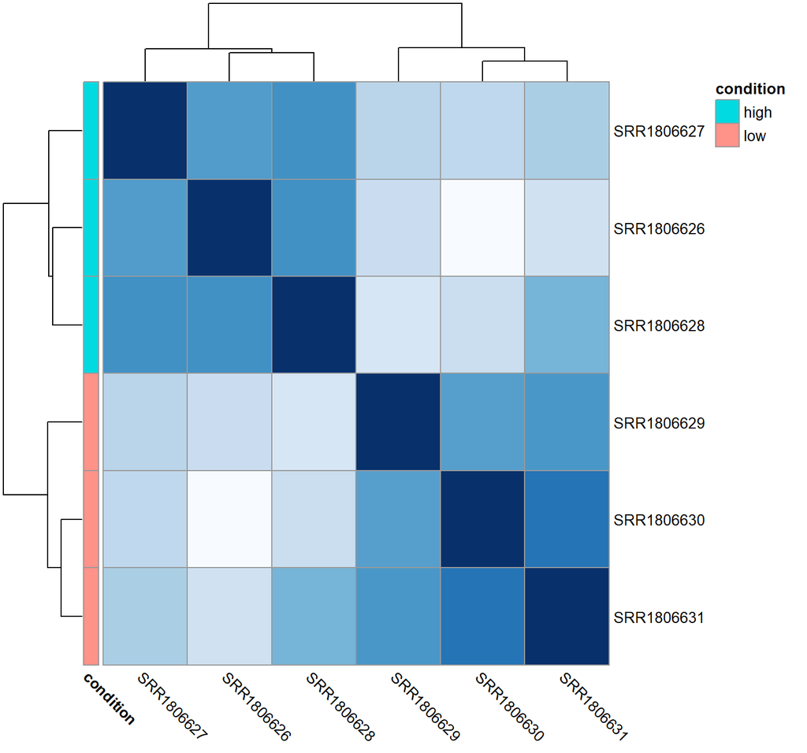

## 2) Differential expression analysis

### 2.1) Calculation of DEGs using `DESeq2`

Differentially-expressed genes (DEGs) were calculated using the R package `DESeq2` with default settings. The used design matrix in this analysis was the comparison of the two levels of condition, high and low.

A DEG was classified as significant when it showed an adjusted p-value smaller 0.01, a log2 fold change greater than or equal 1 and a base mean greater than or equal 20.

|  | baseMean | log2FoldChange | lfcSE | stat | pvalue | padj | GENEID | SYMBOL |
| --- | --- | --- | --- | --- | --- | --- | --- | --- |
| ENSG00000105492.16 | 153.277371247048 | -5.07338949235715 | 0.319853953982598 | -11.9978254375036 | 3.64754168245367e-33 | 3.77906774429744e-30 | ENSG00000105492 | SIGLEC6 |
| ENSG00000269404.7 | 133.417229575943 | -4.13422021111062 | 0.318539872751535 | -11.837178076223 | 2.50748490499885e-32 | 2.10306341103547e-29 | ENSG00000269404 | SPIB |
| ENSG00000137265.15 | 93.8208956589566 | -4.10594107162836 | 0.346470367013444 | -10.0064644605003 | 1.42763573911344e-23 | 4.12212266770575e-21 | ENSG00000137265 | IRF4 |
| ENSG00000196562.14 | 272.245748771852 | -4.0554011034761 | 0.267628248730561 | -14.6946627910367 | 6.97448121873682e-49 | 4.09471792352038e-45 | ENSG00000196562 | SULF2 |
| ENSG00000114923.17 | 79.2468139989407 | -4.02322367222751 | 0.348590557668417 | -9.54539672090167 | 1.35587649910612e-21 | 3.14224378667844e-19 | ENSG00000114923 | SLC4A3 |
| ENSG00000110042.8 | 245.89990276907 | -3.91521048180947 | 0.263625372397473 | -14.4105248412342 | 4.44321066685373e-47 | 1.5651653895059e-43 | ENSG00000110042 | DTX4 |
| ENSG00000239961.3 | 65.2130080362472 | -3.84976050080751 | 0.359195432303738 | -8.66522502255827 | 4.50622066955907e-18 | 6.84207453904688e-16 | ENSG00000239961 | LILRA4 |
| ENSG00000101347.11 | 3413.55982170704 | -3.83982645273233 | 0.237018302626418 | -16.1863416432185 | 6.29623845872641e-59 | 1.10895647973548e-54 | ENSG00000101347 | SAMHD1 |
| ENSG00000132514.14 | 42.2232027891713 | -3.8153866504049 | 0.374283869779594 | -6.41008903252716 | 1.45434679819006e-10 | 7.57852371494722e-09 | ENSG00000132514 | CLEC10A |
| ENSG00000186818.12 | 240.666212120535 | -3.76241591566066 | 0.25929935490115 | -14.1281204437924 | 2.54855963765897e-45 | 7.48129681634791e-42 | ENSG00000186818 | LILRB4 |

[output cut: 975 more lines]

## 3) Plotting results

### 3.1) MA plot

Relationship between intensity and difference between log fold change and mean of normalized counts for conditions high and low.

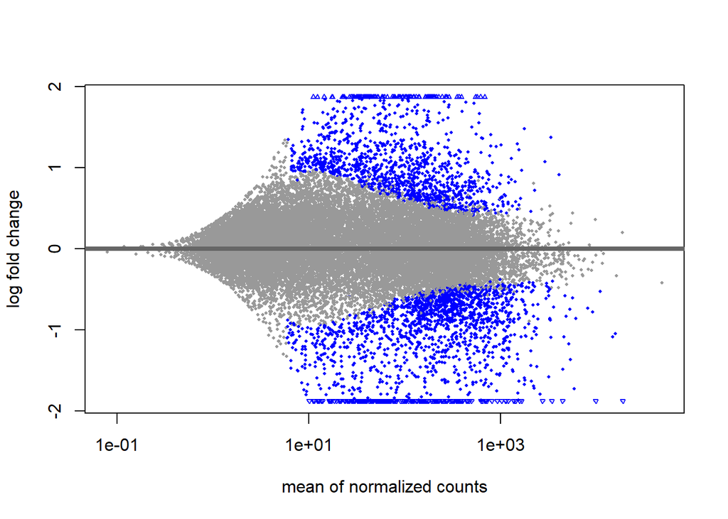

### 3.2) Create a Volcano Plot

The correlation of effect size (`Log2 fold change`) and significance (`-Log10P`) showed a number of significant DEGs (colored in red).

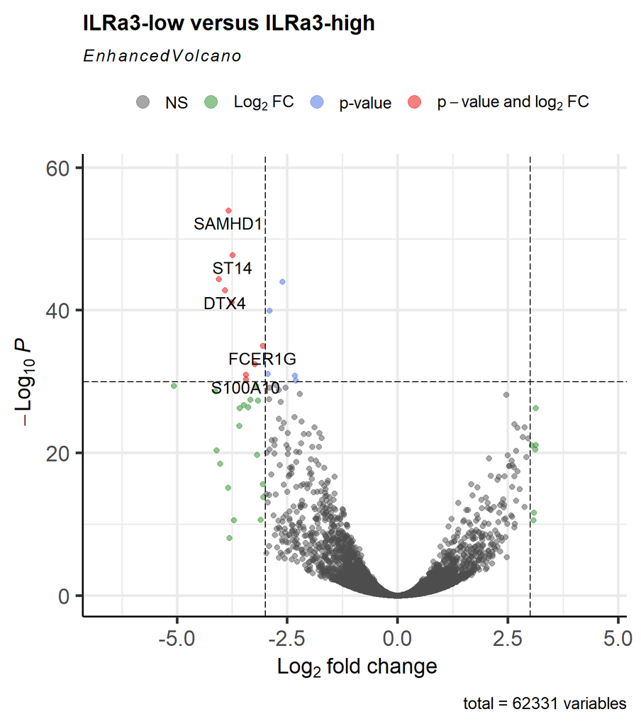

## 4) Heatmap showing the top 20 over- and under-expressed DEGs

The top 20 over- and under-expressed DEGs were identified based on their effect size (`Log2 fold change`). The 20 DEGs with the highest and the 20 DEGs with the lowest effect size were selected.

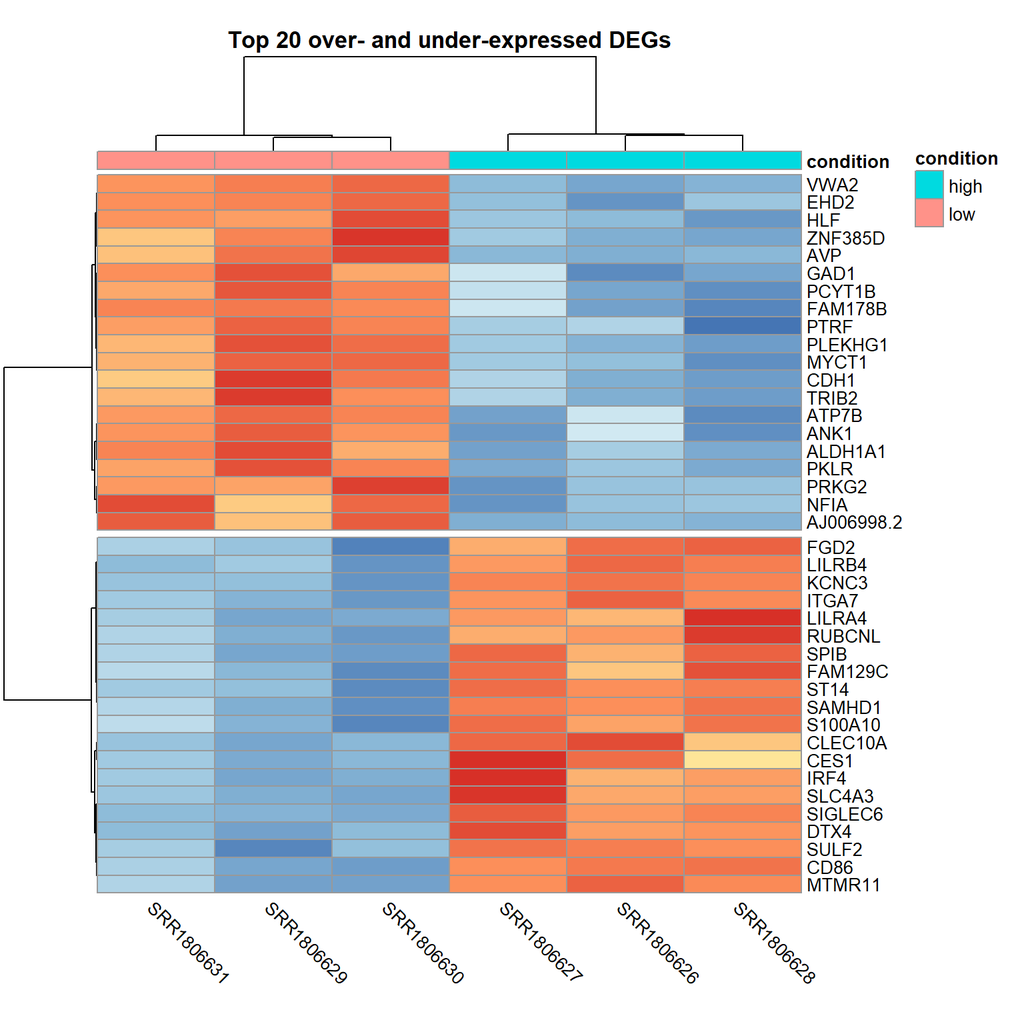

## 5) Top 5 pathways of `GSEA` of DEGs

Gene set enrichment analysis (GSEA) was performed with `-log10(FDR)*sign(log2FoldChange)` as the ranking metric and using all available gene set annotations from MSIGDB.

The histogram below shows the calculated GSEA metric for this analyzed data.

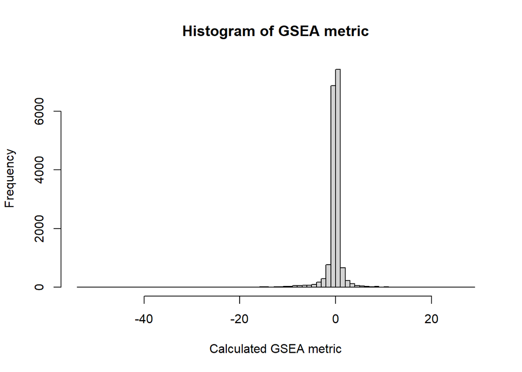

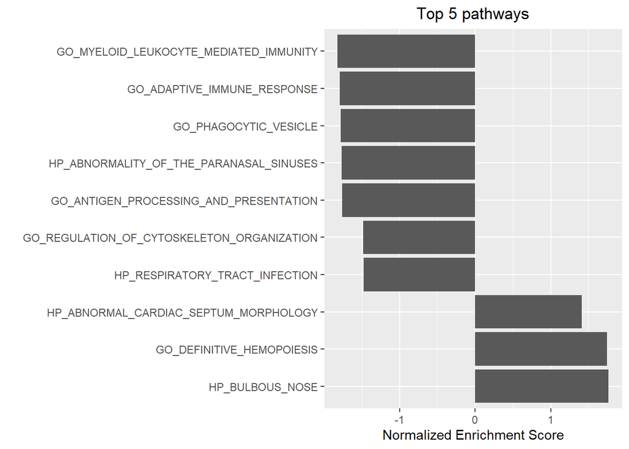

How to interpret these plots?

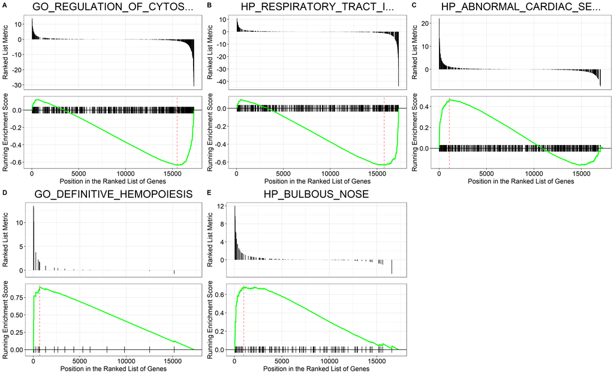

### 5.2) Top 5 under-expressed pathways

The plot below shows the top 5 under-expressed pathways for our GSEA.

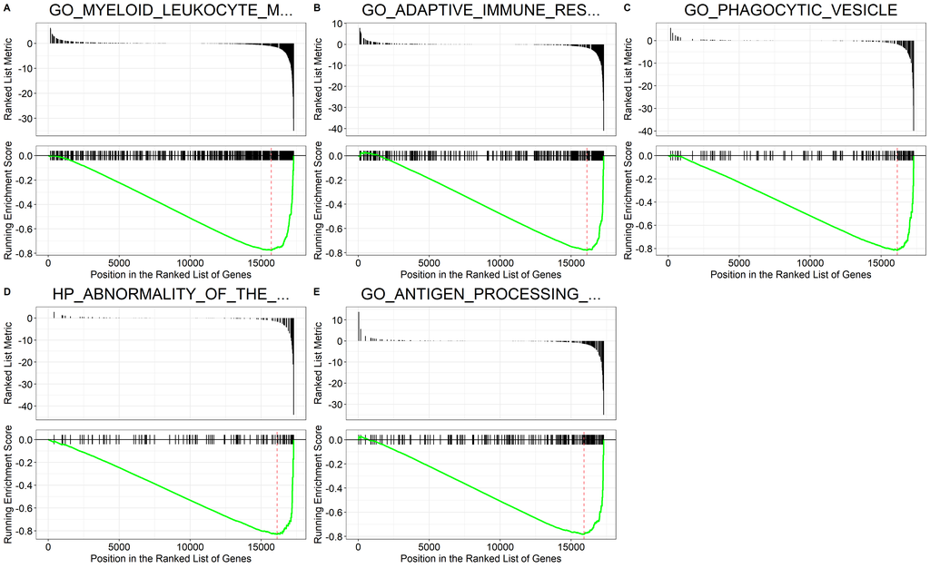

### 5.3) Table of all significant pathways

137 significant results for the conducted GSEA were found based on an adjusted p-value smaller than or equal to 0.05 (see **Table 3**).

|  | NES | pvalue | p.adjust | core_enrichment |
| --- | --- | --- | --- | --- |
| HP_BULBOUS_NOSE | 1.76367305669272 | 0.000278601648510187 | 0.0234714992789424 | SHANK3/KDM5B/FBN1/ECE1/MPDZ/FREM1/MMP2/ARVCF/STXBP1/DOCK6/RREB1/PIGV/MBD5/PYCR1/OBSL1/PIGL |
| GO_DEFINITIVE_HEMOPOIESIS | 1.7458606361037 | 0.000696556085806462 | 0.0455922748779014 | TAL1/GATA1/MEIS1/ZFPM1/RBFOX2/HOXB3/HOXB4/TEK |
| HP_ABNORMAL_CARDIAC_SEPTUM_MORPHOLOGY | 1.41370376697808 | 0.000308371617303338 | 0.0250910283564897 | ANK1/MCTP2/GATA1/COL5A1/SHANK3/CHRM3/KDM5B/FBN1/ROBO4/ECE1/C…… |
| HP_RESPIRATORY_TRACT_INFECTION | -1.47646890783273 | 0.00050933948117213 | 0.0361164137107805 | DOCK8/ORC6/MYO5A/USB1/ECM1/KIF20A/WDR34/B2M/NFKB1/AP3D1/FUCA…… |
| GO_REGULATION_OF_CYTOSKELETON_ORGANIZATION | -1.48319592621241 | 0.000120165098203318 | 0.014006641378247 | SKA3/SLC9A1/MEF2C/INPP5K/ARF1/TPX2/ARHGDIB/STIL/PLK4/GPM6B/S…… |
| GO_SIDE_OF_MEMBRANE | -1.48777783667387 | 0.000288797135442227 | 0.024091910053705 | IGKC/G6PD/RGS1/MS4A2/KCNAB2/FCN1/ASPSCR1/C2CD2L/CX3CR1/LY75/…… |
| GO_POSITIVE_REGULATION_OF_PROTEIN_KINASE_ACTIVITY | -1.49489407398959 | 0.000133287367811412 | 0.0144523579147253 | CCNB1/AKT1/DAZAP2/CKS1B/CDC6/CDK1/DUSP7/MARK2/TNF/PTPN1/NCKA…… |
| GO_PLASMA_MEMBRANE_PROTEIN_COMPLEX | -1.49515855861929 | 0.000567356928747494 | 0.0389325815057454 | GNG2/GNB5/TLR1/CACNA2D4/B2M/TRAF1/LIME1/FLOT1/ABHD12/TRAF4/PTK2B/TLR2/SCN9A/ATP6AP1/GNB1/INSR/HLA-C/APH1A/GNG7/CBL/APBB1IP/GNAS/SMAD7/CORO1C/CLTB/GNGT2/IFNLR1/HLA-B/GNB2/TMED10/PRKCA/KCNQ1/AP2S1/SLC7A… |
| GO_TAXIS | -1.49668490810307 | 0.000248766093074488 | 0.0227607600642024 | PDGFRB/MAPK3/SPTAN1/CMTM7/CXCR3/AKIRIN1/PTK2B/PADI2/HBEGF/SE…… |
| GO_ACTIN_FILAMENT_ORGANIZATION | -1.50880917899457 | 0.000329051116016617 | 0.0261672518335083 | MYO5A/HSP90B1/MSRB1/CORO6/ARPC1B/FCHSD1/CAPZA1/MAD2L2/NCKAP1…… |

[output cut: 127 more lines]